# Ningaloo Larval Infection Experiment 2024 - PhD Chapter 4

Percent change in size for survivors

```r
# Group by Treatment, Cross_2, and SymbiontTreatment, and calculate mean and standard error for percent change
perc_change_summary <- totaldf_long %>%
  filter(Timepoint == 22, Status == 0) %>%
  group_by(Treatment, Cross_2, SymbiontTreatment, ReefMom) %>%
  summarise(mean_perc_change = mean(PercChangeSize, na.rm = TRUE),
            se_perc_change = sd(PercChangeSize, na.rm = TRUE) / sqrt(n()))

all_combos <- expand.grid(
  Treatment = c("Ambient", "31"),
  Cross_2 = unique(totaldf_long$Cross_2),
  SymbiontTreatment = unique(totaldf_long$SymbiontTreatment),
  ReefMom = unique (totaldf_long$ReefMom),
  stringsAsFactors = FALSE
)

perc_change_summary <- all_combos %>%
  left_join(perc_change_summary, by = c("Treatment", "Cross_2", "SymbiontTreatment", "ReefMom")) %>%
  mutate(
    mean_area = ifelse(is.na(mean_perc_change), 0, mean_perc_change),
    se_area = ifelse(is.na(se_perc_change), 0, se_perc_change),
    Treatment = factor(Treatment, levels = c("Ambient", "31", "35.5"))  # Re-set factor levels
  )

# Define a custom color palette (same as before)
custom_colors <- c("CC" = "#1f77b4", "WW" = "#ff7f0e")  # Modify colors as needed

# Plot percent change in area with colors assigned to Cross_2 and separate panels for Family
survivors_perc_change <- ggplot(perc_change_summary, aes(x = Treatment, y = mean_perc_change,
                                                        fill = Cross_2, shape = SymbiontTreatment)) +
  geom_line(aes(group = interaction(Cross_2, SymbiontTreatment), color = Cross_2), size = 0.7) +  # connecting lines
  geom_point(size = 4, color = "black", stroke = 1.5) +  # points with black border
  geom_errorbar(aes(ymin = mean_perc_change - se_perc_change,
                    ymax = mean_perc_change + se_perc_change,
                    color = Cross_2), width = 0.2) +  # error bars matching fill color
  geom_hline(yintercept = 0, linetype = "dashed", color = "grey") +
  scale_fill_manual(values = custom_colors) +  # fill for points
  scale_color_manual(values = custom_colors) + # color for error bars and lines
  scale_shape_manual(values = c(21, 24)) + # shapes that support fill + border
  facet_wrap(~ ReefMom, nrow = 7) +
  labs(x = "Temperature (Treatment)", y = "Percent Change in Area (mm² ± s.e.)",
       title = "Percent Change in Larval Area (Survived to Timepoint 22)") +
  theme_minimal() +
  theme(
    legend.position = "right",
    panel.grid.major = element_blank(),
    panel.grid.minor = element_blank(),
    axis.line = element_line(color = "black", linewidth = 0.5),
    axis.ticks = element_line(color = "black")
  )


print(survivors_perc_change)

# Save the plot to a file
ggsave("percent_change_area_plot.png",
       plot = survivors_perc_change,  # Save the most recent plot
       width = 10,          # Set the width of the plot (in inches)
       height = 7,          # Set the height of the plot (in inches)
       dpi = 300)           # Set the resolution (300 dpi is good for publications)
```

Combine the 3 plots for size into one figure

```r
# Combine the three plots into one figure
combined_plot2 <- area_plot +  theme(legend.position = "none") +
  perc_change_plot +  theme(legend.position = "none") +
  survivors_perc_change +  theme(legend.position = "none") +
  plot_layout(ncol = 3)  # Stack them vertically (1 column)

# Display the combined plot
print(combined_plot2)

ggsave("C:/Users/bellb/OneDrive - James Cook University/Australia/Ningaloo Spawning 2024/combined_plot_size.png",
       plot = combined_plot2,  # Save the most recent plot
       width = 10,          # Set the width of the plot (in inches)
       height = 7,          # Set the height of the plot (in inches)
       dpi = 300)           # Set the resolution (300 dpi is good for publications)
```

Plot of mean FV/FM at T22 (first measurements taken at T4)

```r
# Filter the dataframe to get data for the final timepoint (22)
final_timepoint_fvfm_df <- totaldf_long %>%
  filter(Timepoint == 22) %>%
  group_by(Treatment, Cross_2, SymbiontTreatment) %>%
  summarise(mean_fvfm = mean(FvFm, na.rm = TRUE),
            se_fvfm = sd(FvFm, na.rm = TRUE) / sqrt(n()))

# Reorder the Treatment factor in the desired order
final_timepoint_fvfm_df <- final_timepoint_fvfm_df %>%
  mutate(Treatment = factor(Treatment, levels = c("Ambient", "31", "35.5")))

# Identify all combinations that should be present
all_combos <- expand.grid(
  Treatment = c("Ambient", "31", "35.5"),
  SymbiontTreatment = unique(final_timepoint_fvfm_df$SymbiontTreatment),
  Cross_2 = unique(final_timepoint_fvfm_df$Cross_2)
)

# Join with existing data
final_timepoint_fvfm_df <- all_combos %>%
  left_join(final_timepoint_fvfm_df, by = c("Treatment", "SymbiontTreatment", "Cross_2")) %>%
  mutate(
    Timepoint = 22,
    mean_fvfm = ifelse(is.na(mean_fvfm), 0, mean_fvfm),
    se_fvfm = ifelse(is.na(se_fvfm), 0, se_fvfm)
  )

# Define a custom color palette
custom_colors <- c("BxB" = "#1f77b4", "TxT" = "#ff7f0e") # Modify colors as needed

# Plot the mean area with error bars and custom colors
fvfm_plot <- ggplot(final_timepoint_fvfm_df, aes(x = Treatment, y = mean_fvfm,
                                                 fill = Cross_2, shape = SymbiontTreatment)) +
  # Error bars match fill color
  geom_errorbar(aes(ymin = mean_fvfm - se_fvfm, ymax = mean_fvfm + se_fvfm,
                    color = Cross_2),
                width = 0.2) +

  # Reference line
  geom_hline(yintercept = 0, linetype = "dashed", color = "grey") +

  # Points with fill and black border
  geom_point(size = 4, stroke = 1.2, color = "black") +

  # Manual color settings
  scale_fill_manual(values = custom_colors) +
  scale_color_manual(values = custom_colors) +
  scale_shape_manual(values = c("C" = 21, "D" = 24)) +

  # Labels and theme
  labs(x = "Temperature Treatment",
       y = "Mean Fv/Fm (± s.e.)",
       title = "Mean Larval Fv/Fm at Final Timepoint (22)") +
  theme_minimal() +
  theme(
    legend.position = "right",
    panel.grid.major = element_blank(),
    panel.grid.minor = element_blank(),
    axis.line = element_line(color = "black"),
    axis.ticks = element_line(color = "black")
  )

fvfm_plot

# Create inset for the above plot
# Step 1: Filter the dataframe to get data for the final timepoint (22)

# Reorder the Treatment factor in the desired order
totaldf_long <- totaldf_long %>%
  mutate(Treatment = factor(Treatment, levels = c("Ambient", "31", "35.5")))

final_timepoint_fvfm_df_inset <- totaldf_long %>%
  filter(Treatment != "35.5") %>%
  filter(Timepoint == 22) %>%
  group_by(Treatment) %>%
  summarise(mean_fvfm = mean(FvFm, na.rm = TRUE),
            se_fvfm = sd(FvFm, na.rm = TRUE) / sqrt(n()))

# Step 2: Create the plot
mean_fvfm_plot <- ggplot(final_timepoint_fvfm_df_inset, aes(x = Treatment, y = mean_fvfm)) +
  geom_point(size = 4, shape = 1, fill = NA, stroke = 1.5) +  # Adjust point size as needed
  geom_errorbar(aes(ymin = mean_fvfm - se_fvfm, ymax = mean_fvfm + se_fvfm),
                width = 0.2) +
  labs(x = "Temperature (Treatment)", y = "Mean Fv/Fm (± s.e.)",
       title = "Mean Larval Fv/Fm at Final Timepoint (All Crosses and Symbiont Treatments)") +
  theme_minimal() +
  theme(
    panel.grid.major = element_blank(),  # Remove major grid lines
    panel.grid.minor = element_blank(),  # Remove minor grid lines
    axis.line = element_line(color = "black", linewidth = 0.5)  # Keep axis lines
  )

# Step 4: Display the plot
print(mean_fvfm_plot)

# Create inset for the above plot seperated by Treatment and Symbiont treatment
# Step 1: Filter the dataframe to get data for the final timepoint (22)
final_timepoint_fvfm_df_inset2 <- totaldf_long %>%
  filter(Treatment != "35.5") %>%
  filter(Timepoint == 22) %>%
  group_by(Treatment, SymbiontTreatment) %>%
  summarise(mean_fvfm = mean(FvFm, na.rm = TRUE),
            se_fvfm = sd(FvFm, na.rm = TRUE) / sqrt(n()))

# Reorder the Treatment factor in the desired order
totaldf_long <- totaldf_long %>%
  mutate(Treatment = factor(Treatment, levels = c("Ambient", "31", "35.5")))

# Step 2: Create the plot
mean_fvfm_plot2 <- ggplot(final_timepoint_fvfm_df_inset2, aes(x = Treatment, y = mean_fvfm, shape = SymbiontTreatment)) +
  geom_point(size = 4, fill = NA, stroke = 1.5) +  # Adjust point size as needed
  geom_errorbar(aes(ymin = mean_fvfm - se_fvfm, ymax = mean_fvfm + se_fvfm),
                width = 0.2) +
  labs(x = "Temperature (Treatment)", y = "Mean Fv/Fm (± s.e.)",
       title = "Mean Larval Fv/Fm at Final Timepoint (All Crosses and Symbiont Treatments)") +
  theme_minimal() +
  theme(
    panel.grid.major = element_blank(),  # Remove major grid lines
    panel.grid.minor = element_blank(),  # Remove minor grid lines
    axis.line = element_line(color = "black", linewidth = 0.5)  # Keep axis lines
  )

# Step 4: Display the plot
print(mean_fvfm_plot2)

# Combine the two plots side by side
combined_plot_mean_fvfm <- mean_fvfm_plot + mean_fvfm_plot2 + plot_layout(ncol = 2)

# Display the combined plot
print(combined_plot_mean_fvfm)

# Save the combined plot as a PNG file
ggsave("C:/Users/bellb/OneDrive - James Cook University/Australia/Ningaloo Spawning 2024/combined_plot_mean_fvfm_inset.png", plot = combined_plot_mean_fvfm, width = 6, height = 3, dpi = 300)
```

Plot of raw change in Fv/Fm (% change has too large of error margins for survivors GLMM)

```r
# Group by Treatment, Cross_2, and SymbiontTreatment, and calculate mean and standard error for percent change
raw_change_fvfm_summary <- totaldf_long %>%
  filter(Timepoint == 22, Status == 0) %>%
  group_by(Treatment, Cross_2, SymbiontTreatment) %>%
  summarise(
    mean_raw_change = mean(RawChangeFvFm, na.rm = TRUE),
    se_raw_change = sd(RawChangeFvFm, na.rm = TRUE) / sqrt(n()),
    .groups = "drop"
  )

# Reorder the Treatment factor in the desired order
raw_change_fvfm_summary <- raw_change_fvfm_summary %>%
  mutate(Treatment = factor(Treatment, levels = c("Ambient", "31", "35.5")))

# Identify all combinations that should be present
all_combos <- expand.grid(
  Treatment = c("Ambient", "31", "35.5"),
  SymbiontTreatment = unique(raw_change_fvfm_summary$SymbiontTreatment),
  Cross_2 = unique(raw_change_fvfm_summary$Cross_2)
)

# Join with existing data
raw_change_fvfm_summary <- all_combos %>%
  left_join(raw_change_fvfm_summary, by = c("Treatment", "SymbiontTreatment", "Cross_2")) %>%
  mutate(
    Timepoint = 22,
    raw_pct = ifelse(is.na(mean_raw_change), 0, mean_raw_change),
    se_raw_change = ifelse(is.na(se_raw_change), 0, se_raw_change)
  )

# Define a custom color palette (same as before)
custom_colors <- c("CC" = "#1f77b4", "WW" = "#ff7f0e")  # Modify colors as needed

# Plot the percent change in area with error bars and custom colors
raw_change_fvfm_plot <- ggplot(raw_change_fvfm_summary, aes(
  x = Treatment,
  y = mean_raw_change,
  fill = Cross_2,
  shape = SymbiontTreatment
)) +
  # Error bars colored by Cross_2 (same as fill)
  geom_errorbar(
    aes(
      ymin = mean_raw_change - se_raw_change,
      ymax = mean_raw_change + se_raw_change,
      color = Cross_2
    ),
    width = 0.2
  ) +
  # Points with colored fill and black border
  geom_point(
    size = 4,
    stroke = 1.2,
    color = "black"  # black border
  ) +
  geom_hline(yintercept = 0, linetype = "dashed", color = "grey") +
  scale_fill_manual(values = custom_colors) +   # fill for points
  scale_color_manual(values = custom_colors) +  # color for error bars
  scale_shape_manual(values = c("C" = 21, "D" = 24)) +  # circle and triangle
  labs(
    x = "Temperature (Treatment)",
    y = "Raw Change in Fv/Fm (± s.e.)",
    title = "Raw Change in Larval Fv/Fm from Timepoint 4 to 22"
  ) +
  theme_minimal() +
  theme(
    legend.position = "right",
    panel.grid.major = element_blank(),
    panel.grid.minor = element_blank(),
    axis.line = element_line(color = "black"),
    axis.ticks = element_line(color = "black")
  )


# Display the plot
print(raw_change_fvfm_plot)

# Create inset just for treatment
# Group by Treatment and calculate mean and standard error for percent change
raw_change_summary2 <- totaldf_long %>%
  filter(Treatment != "35.5") %>%
  group_by(Treatment) %>%
  summarise(mean_raw_change = mean(RawChangeFvFm, na.rm = TRUE),
            se_raw_change = sd(RawChangeFvFm, na.rm = TRUE) / sqrt(n()))

# Reorder the Treatment factor in the desired order
raw_change_summary2 <- raw_change_summary2 %>%
  mutate(Treatment = factor(Treatment, levels = c("Ambient", "31", "35.5")))

# Plot the percent change in area with error bars and custom colors
raw_change_plot2 <- ggplot(raw_change_summary2, aes(x = Treatment, y = mean_raw_change)) +
  geom_point(size = 4, shape = 1, stroke = 1.5) +
  geom_errorbar(aes(ymin = mean_raw_change - se_raw_change, ymax = mean_raw_change + se_raw_change),
                width = 0.2) +
  geom_hline(yintercept = 0, linetype = "dashed", color = "grey") +  # Add dashed line at y = 0
  labs(x = "Temperature (Treatment)", y = "Raw Change in Fv/Fm (± s.e.)",
       title = "Raw Change in Larval Fv/Fm from Timepoint 4 to 22") +
  theme_minimal() +
  theme(
    legend.position = "right",
    panel.grid.major = element_blank(),  # Remove major grid lines
    panel.grid.minor = element_blank(),  # Remove minor grid lines
    axis.line = element_line(color = "black"),  # Keep x and y axis lines
    axis.ticks = element_line(color = "black")  # Add axis ticks
  )

# Display the plot
print(raw_change_plot2)

# Create inset for treatment and symbiont treatment
# Group by Treatment and SymbiontTreatment, and calculate mean and standard error for percent change
raw_change_summary3 <- totaldf_long %>%
  filter(Treatment != "35.5") %>%
  group_by(Treatment, SymbiontTreatment) %>%
  summarise(mean_raw_change = mean(RawChangeFvFm, na.rm = TRUE),
            se_raw_change = sd(RawChangeFvFm, na.rm = TRUE) / sqrt(n()))

# Reorder the Treatment factor in the desired order
raw_change_summary3 <- raw_change_summary3 %>%
  mutate(Treatment = factor(Treatment, levels = c("Ambient", "31", "35.5")))

# Plot the percent change in area with error bars and custom colors
raw_change_plot3 <- ggplot(raw_change_summary3, aes(x = Treatment, y = mean_raw_change, shape = SymbiontTreatment)) +
  geom_point(size = 4, stroke = 1.5) +
  geom_errorbar(aes(ymin = mean_raw_change - se_raw_change, ymax = mean_raw_change + se_raw_change),
                width = 0.2) +
  geom_hline(yintercept = 0, linetype = "dashed", color = "grey") +  # Add dashed line at y = 0
  labs(x = "Temperature (Treatment)", y = "Raw Change in Fv/Fm (± s.e.)",
       title = "Raw Change in Larval Fv/Fm from Timepoint 4 to 22") +
  theme_minimal() +
  theme(
    legend.position = "right",
    panel.grid.major = element_blank(),  # Remove major grid lines
    panel.grid.minor = element_blank(),  # Remove minor grid lines
    axis.line = element_line(color = "black"),  # Keep x and y axis lines
    axis.ticks = element_line(color = "black")  # Add axis ticks
  )

# Display the plot
print(raw_change_plot3)

library(patchwork)

# Combine the two plots side by side
combined_plot_raw_fvfm <- raw_change_plot2 + raw_change_plot3 + plot_layout(ncol = 2)

# Display the combined plot
print(combined_plot_raw_fvfm)

# Save the combined plot as a PNG file
ggsave("C:/Users/jc980786/OneDrive - James Cook University/Australia/Ningaloo Spawning 2024/combined_plot_raw_fvfm_inset.png", plot = combined_plot_raw_fvfm, width = 6, height = 3, dpi = 300)
```

Raw change in FVFM for survivors

```r
# Group by Treatment, Cross_2, and SymbiontTreatment, and calculate mean and standard error for percent change
raw_change_fvfm_summary <- totaldf_long %>%
  filter(Timepoint == 22, Status == 0) %>%
  group_by(Treatment, Cross_2, SymbiontTreatment, ReefMom) %>%
  summarise(
    mean_raw_change = mean(RawChangeFvFm, na.rm = TRUE),
    se_raw_change = sd(RawChangeFvFm, na.rm = TRUE) / sqrt(n()),
    .groups = "drop"
  )

# Reorder the Treatment factor in the desired order
raw_change_fvfm_summary <- raw_change_fvfm_summary %>%
  mutate(Treatment = factor(Treatment, levels = c("Ambient", "31", "35.5")))

# Identify all combinations that should be present
all_combos <- expand.grid(
  Treatment = c("Ambient", "31"),
  SymbiontTreatment = unique(raw_change_fvfm_summary$SymbiontTreatment),
  Cross_2 = unique(raw_change_fvfm_summary$Cross_2),
  ReefMom = unique(raw_change_fvfm_summary$ReefMom)
)

# Join with existing data
raw_change_fvfm_summary <- all_combos %>%
  left_join(raw_change_fvfm_summary, by = c("Treatment", "SymbiontTreatment", "Cross_2", "ReefMom")) %>%
  mutate(
    Timepoint = 22,
    mean_raw = ifelse(is.na(mean_raw_change), 0, mean_raw_change),
    se_raw_change = ifelse(is.na(se_raw_change), 0, se_raw_change)
  )

# Define a custom color palette (same as before)
custom_colors <- c("CC" = "#1f77b4", "WW" = "#ff7f0e")  # Modify colors as needed

# Plot percent change in area with colors assigned to Cross_2 and separate panels for Family
survivors_raw_change <- ggplot(raw_change_fvfm_summary, aes(
  x = Treatment,
  y = mean_raw_change,
  fill = Cross_2,
  shape = SymbiontTreatment,
  group = interaction(Cross_2, SymbiontTreatment)
)) +
  # Colored lines connecting points
  geom_line(aes(color = Cross_2), linewidth = 0.8) +

  # Error bars colored by fill
  geom_errorbar(aes(
    ymin = mean_raw_change - se_raw_change,
    ymax = mean_raw_change + se_raw_change,
    color = Cross_2
  ), width = 0.2) +

  # Points with black border and colored fill
  geom_point(size = 4, stroke = 1.2, color = "black") +

  # Reference line at 0
  geom_hline(yintercept = 0, linetype = "dashed", color = "grey") +

  # Manual color and shape control
  scale_fill_manual(values = custom_colors) +
  scale_color_manual(values = custom_colors) +
  scale_shape_manual(values = c("C" = 21, "D" = 24)) +

  # Labels and faceting
  labs(
    x = "Temperature (Treatment)",
    y = "Raw Change in Fv/Fm (± s.e.)",
    title = "Raw Change in Larval Fv/Fm (Survived to Timepoint 22)"
  ) +
  facet_wrap(~ ReefMom, nrow = 7) +

  # Theme styling
  theme_minimal() +
  theme(
    legend.position = "right",
    panel.grid.major = element_blank(),
    panel.grid.minor = element_blank(),
    axis.line = element_line(color = "black", linewidth = 0.5),
    axis.ticks = element_line(color = "black")
  )


print(survivors_raw_change)

# Save the plot to a file
ggsave("C:/Users/jc980786/OneDrive - James Cook University/Australia/Ningaloo Spawning 2024/survivors_raw_change_plot.png",
       plot = survivors_raw_change,
       width = 10,
       height = 7,
       dpi = 300)
```

```r
# Combine the three plots into one figure
combined_plot3 <- fvfm_plot + theme(legend.position = "none") +
  raw_change_fvfm_plot + theme(legend.position = "none") +
  survivors_raw_change + theme(legend.position = "none") +
  plot_layout(ncol = 3)  # Stack them vertically (1 column)

# Display the combined plot
print(combined_plot3)

ggsave("C:/Users/jc980786/OneDrive - James Cook University/Australia/Ningaloo Spawning 2024/combined_plot_fvfm_raw.png",
       plot = combined_plot3,
       width = 10,
       height = 7,
       dpi = 300)
```

Percentage of Larvae with Cells: line graphs

```r
library(dplyr)
library(ggplot2)
library(patchwork)  # for plot_layout()

# Replace NA values with zeros in PercentageWithCells column
summary_df2_survived$PercentageWithCells[is.na(summary_df2_survived$PercentageWithCells)] <- 0

summary_df2_survived <- summary_df2_survived %>%
  mutate(Cross = case_when(
    ReefMom %in% c("BT2", "BT4", "BT8") ~ "CC",
    TRUE ~ "WW"
  ))

summary_df2_survived %>%
  group_by(Timepoint, SymbiontTreatment, Treatment) %>%
  summarise(n = sum(!is.na(PercentageWithCells))) %>%
  print(n = Inf)

str(summary_df2_survived$PercentageWithCells)

# Filter the dataframe to get data for the final timepoint (22)
summary_stats_day22 <- summary_df2_survived %>%
  filter(Timepoint == 22) %>%
  group_by(Timepoint, SymbiontTreatment, Treatment, Cross) %>%
  summarise(
    mean_pct = mean(PercentageWithCells, na.rm = TRUE),
    n = sum(!is.na(PercentageWithCells)),
    sd_pct = ifelse(n > 1, sd(PercentageWithCells, na.rm = TRUE), NA_real_),
    se = ifelse(n > 1, sd_pct / sqrt(n), NA_real_),
    ci_lower = ifelse(n > 1, mean_pct - qt(0.975, df = n - 1) * se, NA_real_),
    ci_upper = ifelse(n > 1, mean_pct + qt(0.975, df = n - 1) * se, NA_real_)
  ) %>%
  ungroup()

# Set factor levels BEFORE plotting, to retain all x-axis categories
summary_stats_day22 <- summary_stats_day22 %>%
  mutate(Treatment = factor(Treatment, levels = c("Ambient", "31", "35.5")))

# Make a full combination of all groups you'd expect at Timepoint 22
all_combos <- expand.grid(
  Treatment = c("Ambient", "31", "35.5"),
  SymbiontTreatment = unique(summary_stats_day22$SymbiontTreatment),
  Cross = unique(summary_stats_day22$Cross)
)

# Merge with your summary data
summary_stats_day22 <- all_combos %>%
  left_join(summary_stats_day22, by = c("Treatment", "SymbiontTreatment", "Cross")) %>%
  mutate(
    Timepoint = 22,
    mean_pct = ifelse(is.na(mean_pct), 0, mean_pct),
    se = ifelse(is.na(se), 0, se),
    TREATMENT = factor(Treatment, levels = c("Ambient", "31", "35.5"))
  )

summary_stats_day22$SymbiontTreatment <- factor(
  summary_stats_day22$SymbiontTreatment,
  levels = c("C", "D")  # or whatever levels you actually have
)

# Reorder the Treatment factor in the desired order
#final_timepoint_df <- final_timepoint_df %>%
#  mutate(TREATMENT = factor(TREATMENT, levels = c("Ambient", "31", "35.5")))

# Define a custom color palette
custom_colors <- c("CC" = "#1f77b4", "WW" = "#ff7f0e") # Modify as needed

# Plot mean PercentageWithCells with error bars and custom colors
pct_plot <- ggplot(summary_stats_day22, aes(
  x = Treatment,
  y = mean_pct,
  fill = Cross,
  shape = SymbiontTreatment
)) +
  # Error bars take the fill color
  geom_errorbar(
    aes(ymin = mean_pct - se, ymax = mean_pct + se, color = Cross),
    width = 0.2
  ) +

  # Points with black outlines and colored fill
  geom_point(
    size = 4,
    stroke = 1.2,
    color = "black"  # black border
  ) +

  geom_hline(yintercept = 0, linetype = "dashed", color = "grey") +

  scale_fill_manual(values = custom_colors) +
  scale_color_manual(values = custom_colors) +  # for error bars
  scale_shape_manual(values = c("C" = 21, "D" = 24)) +

  labs(
    x = "Temperature Treatment",
    y = "Mean % With Cells (± s.e.)",
    title = "Mean Percentage With Cells at Final Timepoint (22)"
  ) +

  theme_minimal() +
  theme(
    legend.position = "right",
    panel.grid.major = element_blank(),
    panel.grid.minor = element_blank(),
    axis.line = element_line(color = "black"),
    axis.ticks = element_line(color = "black")
  )

print(pct_plot)

# Create inset plot by Treatment only
final_timepoint_df_inset <- summary_df2_survived %>%
  filter(TIMEPOINT == 22) %>%
  group_by(TREATMENT) %>%
  summarise(
    mean_pct = mean(PercentageWithCells, na.rm = TRUE),
    se_pct = sd(PercentageWithCells, na.rm = TRUE) / sqrt(n())
  ) %>%
  mutate(Treatment = factor(TREATMENT, levels = c("T1", "T2", "T3")))

mean_pct_plot <- ggplot(final_timepoint_df_inset, aes(x = TREATMENT, y = mean_pct)) +
  geom_point(size = 4, shape = 1, fill = NA, stroke = 1.5) +
  geom_errorbar(aes(ymin = mean_pct - se_pct, ymax = mean_pct + se_pct), width = 0.2) +
  labs(x = "Temperature Treatment", y = "Mean % With Cells (± s.e.)",
       title = "Mean Percentage With Cells at Final Timepoint (All Crosses and Symbiont Treatments)") +
  theme_minimal() +
  theme(
    panel.grid.major = element_blank(),
    panel.grid.minor = element_blank(),
    axis.line = element_line(color = "black", linewidth = 0.5)
  )

print(mean_pct_plot)

# Create inset plot separated by Treatment and SymbiontTreatment
final_timepoint_df_inset2 <- summary_df3_survived %>%
  filter(DayNumber == 22) %>%
  group_by(TREATMENT, SymbiontTreatment) %>%
  summarise(
    mean_pct = mean(PercentageWithCells, na.rm = TRUE),
    se_pct = sd(PercentageWithCells, na.rm = TRUE) / sqrt(n())
  ) %>%
  mutate(Treatment = factor(TREATMENT, levels = c("Ambient", "31", "35.5")))

mean_pct_plot2 <- ggplot(final_timepoint_df_inset2, aes(x = TREATMENT, y = mean_pct, shape = SymbiontTreatment)) +
  geom_point(size = 4, fill = NA, stroke = 1.5) +
  geom_errorbar(aes(ymin = mean_pct - se_pct, ymax = mean_pct + se_pct), width = 0.2) +
  labs(x = "Temperature Treatment", y = "Mean % With Cells (± s.e.)",
       title = "Mean Percentage With Cells at Final Timepoint (All Crosses and Symbiont Treatments)") +
  theme_minimal() +
  theme(
    panel.grid.major = element_blank(),
    panel.grid.minor = element_blank(),
    axis.line = element_line(color = "black", linewidth = 0.5)
  )

print(mean_pct_plot2)

# Combine the two inset plots side by side
library(patchwork)

combined_pct_plot <- mean_pct_plot + mean_pct_plot2 + plot_layout(ncol = 2)
print(combined_pct_plot)

# Save combined plot
ggsave("C:/Users/jc980786/OneDrive - James Cook University/Australia/Ningaloo Spawning 2024/combined_plot_mean_percentage_with_cells_inset.png", plot = combined_pct_plot, width = 6, height = 3, dpi = 300)
```

PercentageWithCells from Day 1 to Day 22

```r
summary_df2_survived <- summary_df2_survived %>%
  group_by(SymbiontTreatment, Treatment, Cross) %>%
  mutate(PercentageWithCells_adj = PercentageWithCells + 0.01)

# Extract PercentageWithCells at Day 1
cells_day1 <- summary_df2_survived %>%
  filter(Timepoint == 1) %>%
  dplyr::select(Treatment, ReefMom, SymbiontTreatment, Cross, PercentageWithCells_adj) %>%
  rename(CellsDay1 = PercentageWithCells_adj)

# Extract PercentageWithCells at Day 22
cells_day22 <- summary_df2_survived %>%
  filter(Timepoint == 22) %>%
  dplyr::select(Treatment, ReefMom, SymbiontTreatment, Cross, PercentageWithCells_adj) %>%
  rename(CellsDay22 = PercentageWithCells_adj)

# Join Day 1 and Day 22 data
cells_change_df <- left_join(cells_day1, cells_day22,
                             by = c("Treatment", "ReefMom", "SymbiontTreatment", "Cross"))

# Calculate change
cells_change_df <- cells_change_df <- cells_change_df %>%
  mutate(AcquisitionChangeCells = (CellsDay22) - (CellsDay1))


# Summarize percent change by Treatment, Cross, SymbiontTreatment
perc_change_summary <- cells_change_df %>%
  group_by(Treatment, Cross, SymbiontTreatment) %>%
  summarise(
    mean_perc_change = mean(AcquisitionChangeCells, na.rm = TRUE),
    se_perc_change = sd(AcquisitionChangeCells, na.rm = TRUE) / sqrt(n()),
    .groups = "drop"
  )

# Reorder treatment levels
perc_change_summary <- perc_change_summary %>%
  mutate(Treatment = factor(Treatment, levels = c("Ambient", "31", "35.5")))

# Plot
log_change_plot2 <- ggplot(perc_change_summary, aes(
  x = Treatment,
  y = mean_perc_change,
  fill = Cross,  # use fill instead of color
  shape = SymbiontTreatment
)) +
  # Colored error bars based on Cross
  geom_errorbar(aes(
    ymin = mean_perc_change - se_perc_change,
    ymax = mean_perc_change + se_perc_change,
    color = Cross  # error bar matches fill
  ), width = 0.2) +

  # Points: colored fill, black border
  geom_point(
    size = 4,
    stroke = 1.2,
    color = "black"  # black outline
  ) +

  # Add reference line
  geom_hline(yintercept = 0, linetype = "dashed", color = "grey") +

  # Manual color scales
  scale_fill_manual(values = custom_colors) +   # for fill in points
  scale_color_manual(values = custom_colors) +  # for error bars
  scale_shape_manual(values = c(21, 24)) +      # use filled shapes

  # Labels & styling
  labs(
    x = "Temperature (Treatment)",
    y = "Change in % Larvae With Cells (± s.e.)",
    title = "Change in Symbiotic Larvae from Day 1 to 22"
  ) +
  theme_minimal() +
  theme(
    legend.position = "right",
    panel.grid.major = element_blank(),
    panel.grid.minor = element_blank(),
    axis.line = element_line(color = "black"),
    axis.ticks = element_line(color = "black")
  )


# Show plot
print(log_change_plot2)

# Summarize log change by TREATMENT only
perc_change_inset1 <- cells_change_df %>%
  filter(TREATMENT != "T3") %>%  # Remove T3 before summary
  group_by(TREATMENT) %>%
  summarise(
    mean_perc_change = mean(AcquisitionChangeCells, na.rm = TRUE),
    se_perc_change = sd(AcquisitionChangeCells, na.rm = TRUE) / sqrt(n()),
    .groups = "drop"
  ) %>%
  mutate(Treatment = factor(TREATMENT, levels = c("T1", "T2")))

perc_change_plot_inset1 <- ggplot(perc_change_inset1, aes(x = Treatment, y = mean_perc_change)) +
  geom_point(size = 4, shape = 1, stroke = 1.5) +
  geom_errorbar(aes(ymin = mean_perc_change - se_perc_change,
                    ymax = mean_perc_change + se_perc_change), width = 0.2) +
  labs(x = "Temperature (Treatment)", y = "Change in % With Cells (± s.e.)") +
  theme_minimal() +
  theme(
    panel.grid.major = element_blank(),
    panel.grid.minor = element_blank(),
    axis.line = element_line(color = "black", linewidth = 0.5)
  )

perc_change_inset2 <- cells_change_df %>%
  filter(TREATMENT != "T3") %>%  # Remove T3 before summary
  group_by(TREATMENT, SymbiontTreatment) %>%
  summarise(
    mean_perc_change = mean(AcquisitionChangeCells, na.rm = TRUE),
    se_perc_change = sd(AcquisitionChangeCells, na.rm = TRUE) / sqrt(n()),
    .groups = "drop"
  ) %>%
  mutate(Treatment = factor(TREATMENT, levels = c("T1", "T2")))

perc_change_plot_inset2 <- ggplot(perc_change_inset2, aes(x = Treatment, y = mean_perc_change, shape = SymbiontTreatment)) +
  geom_point(size = 4, stroke = 1.5) +
  geom_errorbar(aes(ymin = mean_perc_change - se_perc_change,
                    ymax = mean_perc_change + se_perc_change), width = 0.2) +
  labs(x = "Temperature (Treatment)", y = "Log Change in % With Cells (± s.e.)") +
  theme_minimal() +
  theme(
    panel.grid.major = element_blank(),
    panel.grid.minor = element_blank(),
    axis.line = element_line(color = "black", linewidth = 0.5)
  )


library(patchwork)

# Combine the insets
combined_perc_change_insets <- perc_change_plot_inset1 + perc_change_plot_inset2 + plot_layout(ncol = 2)

# Print
print(combined_perc_change_insets)

ggsave("C:/Users/bellb/OneDrive - James Cook University/Australia/Ningaloo Spawning 2024/combined_perc_change_insets_pct.png", plot = combined_perc_change_insets,
       width = 6, height = 3, dpi = 300)
```

```r
summary_df2_survived <- summary_df2_survived %>%
  group_by(SymbiontTreatment, TREATMENT, Cross, ReefMom) %>%
  mutate(PercentageWithCells_adj = PercentageWithCells + 0.01)

# Extract PercentageWithCells at Day 1
cells_day1 <- summary_df2_survived %>%
  filter(TIMEPOINT == 1) %>%
  dplyr::select(TREATMENT, ReefMom, SymbiontTreatment, Cross, PercentageWithCells_adj) %>%
  rename(CellsDay1 = PercentageWithCells_adj)

# Extract PercentageWithCells at Day 22
cells_day22 <- summary_df2_survived %>%
  filter(TIMEPOINT == 22) %>%
  dplyr::select(TREATMENT, ReefMom, SymbiontTreatment, Cross, PercentageWithCells_adj) %>%
  rename(CellsDay22 = PercentageWithCells_adj)

# Join Day 1 and Day 22 data
cells_change_df <- left_join(cells_day1, cells_day22,
                             by = c("TREATMENT", "ReefMom", "SymbiontTreatment", "Cross"))

# Calculate log change
cells_change_df <- cells_change_df <- cells_change_df %>%
  mutate(PercChangeCells_Acq = (CellsDay22) - (CellsDay1))

perc_change_summary2 <- cells_change_df %>%
  filter(TREATMENT != "T3") %>%  # Remove T3 before summary
  group_by(TREATMENT, Cross, SymbiontTreatment, ReefMom) %>%
  summarise(
    mean_perc_change = mean(PercChangeCells_Acq, na.rm = TRUE),
    se_perc_change = sd(PercChangeCells_Acq, na.rm = TRUE) / sqrt(n()),
    .groups = "drop"
  )

# Reorder treatment levels
perc_change_summary2 <- perc_change_summary2 %>%
  mutate(Treatment = factor(TREATMENT, levels = c("T1", "T2")))

perc_change_plot3 <- ggplot(perc_change_summary2, aes(
  x = Treatment,
  y = mean_perc_change,
  fill = Cross,
  shape = SymbiontTreatment
)) +
  # Error bars colored by Cross
  geom_errorbar(aes(
    ymin = mean_perc_change - se_perc_change,
    ymax = mean_perc_change + se_perc_change,
    color = Cross
  ), width = 0.2) +

  # Points with black border and colored fill
  geom_point(
    size = 4,
    stroke = 1.2,
    color = "black"  # black outline
  ) +

  geom_hline(yintercept = 0, linetype = "dashed", color = "grey") +

  # Manual scales for fill and shape
  scale_fill_manual(values = custom_colors) +
  scale_color_manual(values = custom_colors) +
  scale_shape_manual(values = c(21, 22)) +

  labs(
    x = "Temperature (Treatment)",
    y = "Percent Change in % Larvae With Cells (± s.e.)",
    title = "Change in Symbiotic Larvae from Day 1 to 22"
  ) +

  facet_wrap(~ ReefMom, nrow = 7) +

  theme_minimal() +
  theme(
    legend.position = "right",
    panel.grid.major = element_blank(),
    panel.grid.minor = element_blank(),
    axis.line = element_line(color = "black"),
    axis.ticks = element_line(color = "black")
  )


# Display the faceted plot
print(perc_change_plot3)

perc_change_plot3 <- ggplot(perc_change_summary2, aes(
  x = Treatment,
  y = mean_perc_change,
  fill = Cross,
  shape = SymbiontTreatment
)) +
  # Lines connecting points of same Cross and SymbiontTreatment
  geom_line(aes(
    group = interaction(Cross, SymbiontTreatment),
    color = Cross
  ), linewidth = 0.8) +

  # Error bars colored by Cross
  geom_errorbar(aes(
    ymin = mean_perc_change - se_perc_change,
    ymax = mean_perc_change + se_perc_change,
    color = Cross
  ), width = 0.2) +

  # Points with colored fill and black border
  geom_point(
    size = 4,
    stroke = 1.2,
    color = "black"
  ) +

  geom_hline(yintercept = 0, linetype = "dashed", color = "grey") +

  # Scales and labels
  scale_fill_manual(values = custom_colors) +
  scale_color_manual(values = custom_colors) +
  scale_shape_manual(values = c(21, 24)) +

  labs(
    x = "Temperature (Treatment)",
    y = "Percent Change in % Larvae With Cells (± s.e.)",
    title = "Change in Symbiotic Larvae from Day 1 to 22"
  ) +

  facet_wrap(~ ReefMom, nrow = 7) +

  theme_minimal() +
  theme(
    legend.position = "right",
    panel.grid.major = element_blank(),
    panel.grid.minor = element_blank(),
    axis.line = element_line(color = "black"),
    axis.ticks = element_line(color = "black")
  )
```

Combine all of the plots

```r
# Combine the three plots into one figure
combined_plot_pct <-
  pct_plot +
    theme(legend.position = "none") +
  log_change_plot2 +
    theme(legend.position = "none") +
  perc_change_plot3 +
    theme(legend.position = "none") +
  plot_layout(ncol = 3)


# Display the combined plot
print(combined_plot_pct)

ggsave("C:/Users/bellb/OneDrive - James Cook University/Australia/Ningaloo Spawning 2024/combined_plot_pct_updated.png",
       plot = combined_plot_pct,  # Save the most recent plot
       width = 10,          # Set the width of the plot (in inches)
       height = 7,          # Set the height of the plot (in inches)
       dpi = 300)           # Set the resolution (300 dpi is good for publications)
```

Line graphs of Cell Density

```r
library(dplyr)
library(ggplot2)
library(patchwork)

# Replace NA values with zeros in Cell_Density
df_subset$Cell_Density[is.na(df_subset$Cell_Density)] <- 0

# Define crosses (adjust as needed)
df_subset <- df_subset %>%
  mutate(Cross = case_when(
    ReefMom %in% c("BT2", "BT4", "BT8") ~ "CC",
    TRUE ~ "WW"
  ))

# Set factor levels BEFORE plotting, to retain all x-axis categories
df_subset <- df_subset %>%
  mutate(Treatment = factor(Treatment, levels = c("Ambient", "31", "35.5")))

# Filter for Day 22 and summarize
summary_stats_day22_cd <- df_subset %>%
  filter(Timepoint == 22) %>%
  group_by(Timepoint, SymbiontTreatment, Treatment, Cross) %>%
  summarise(
    mean_cd = mean(Cell_Density, na.rm = TRUE),
    n = sum(!is.na(Cell_Density)),
    sd_cd = ifelse(n > 1, sd(Cell_Density, na.rm = TRUE), NA_real_),
    se = ifelse(n > 1, sd_cd / sqrt(n), NA_real_),
    ci_lower = ifelse(n > 1, mean_cd - qt(0.975, df = n - 1) * se, NA_real_),
    ci_upper = ifelse(n > 1, mean_cd + qt(0.975, df = n - 1) * se, NA_real_)
  ) %>%
  ungroup()

# Identify all combinations that should be present
all_combos <- expand.grid(
  Treatment = c("Ambient", "31", "35.5"),
  SymbiontTreatment = unique(summary_stats_day22_cd$SymbiontTreatment),
  Cross = unique(summary_stats_day22_cd$Cross)
)

# Join with existing data
summary_stats_day22_cd <- all_combos %>%
  left_join(summary_stats_day22_cd, by = c("Treatment", "SymbiontTreatment", "Cross")) %>%
  mutate(
    Timepoint = 22,
    mean_cd = ifelse(is.na(mean_cd), 0, mean_cd),
    se = ifelse(is.na(se), 0, se)
  )

# Define custom colors
custom_colors <- c("CC" = "#1f77b4", "WW" = "#ff7f0e")

# Plot main Cell Density plot
cd_plot <- ggplot(summary_stats_day22_cd, aes(
  x = Treatment,
  y = mean_cd,
  fill = Cross,                    # fill color by Cross
  shape = SymbiontTreatment        # shape by symbiont
)) +
  geom_errorbar(
    aes(ymin = mean_cd - se, ymax = mean_cd + se, color = Cross),
    width = 0.2
  ) +
  geom_point(
    size = 4,
    stroke = 1.2,
    color = "black"                # black border
  ) +
  geom_hline(yintercept = 0, linetype = "dashed", color = "grey") +
  scale_fill_manual(values = custom_colors) +
  scale_color_manual(values = custom_colors) +  # for error bars
  scale_shape_manual(values = c("C" = 21, "D" = 24)) +
  labs(
    x = "Temperature Treatment",
    y = "Mean Cell Density (± s.e.)",
    title = "Mean Cell Density at Final Timepoint (22)"
  ) +
  theme_minimal() +
  theme(
    legend.position = "right",
    panel.grid.major = element_blank(),
    panel.grid.minor = element_blank(),
    axis.line = element_line(color = "black"),
    axis.ticks = element_line(color = "black")
  )


print(cd_plot)

ggsave("C:/Users/bellb/OneDrive - James Cook University/Australia/Ningaloo Spawning 2024/Larval Infection Experiment/cell_density_mean_plot.png", plot = cd_plot,
       width = 6, height = 3, dpi = 300)

#Mean cell density by Treatment
final_timepoint_df_inset_cd <- df_subset %>%
  filter(Timepoint == 22) %>%
  group_by(Treatment) %>%
  summarise(
    mean_cd = mean(Cell_Density, na.rm = TRUE),
    se_cd = sd(Cell_Density, na.rm = TRUE) / sqrt(n())
  ) %>%
  mutate(Treatment = factor(Treatment, levels = c("Ambient", "31", "35.5")))

mean_cd_plot <- ggplot(final_timepoint_df_inset_cd, aes(x = Treatment, y = mean_cd)) +
  geom_point(size = 4, shape = 1, fill = NA, stroke = 1.5) +
  geom_errorbar(aes(ymin = mean_cd - se_cd, ymax = mean_cd + se_cd), width = 0.2) +
  labs(x = "Temperature Treatment", y = "Mean Cell Density (± s.e.)",
       title = "Mean Cell Density at Final Timepoint (All Crosses and Symbiont Treatments)") +
  theme_minimal() +
  theme(
    panel.grid.major = element_blank(),
    panel.grid.minor = element_blank(),
    axis.line = element_line(color = "black", linewidth = 0.5)
  )
print(mean_cd_plot)

#Inset by Treatment x SymbiontTreatment
final_timepoint_df_inset_cd2 <- df_subset %>%
  filter(Timepoint == 22) %>%
  group_by(Treatment, SymbiontTreatment) %>%
  summarise(
    mean_cd = mean(Cell_Density, na.rm = TRUE),
    se_cd = sd(Cell_Density, na.rm = TRUE) / sqrt(n())
  ) %>%
  mutate(Treatment = factor(Treatment, levels = c("Ambient", "31", "35.5")))

mean_cd_plot2 <- ggplot(final_timepoint_df_inset_cd2, aes(x = Treatment, y = mean_cd, shape = SymbiontTreatment)) +
  geom_point(size = 4, fill = NA, stroke = 1.5) +
  geom_errorbar(aes(ymin = mean_cd - se_cd, ymax = mean_cd + se_cd), width = 0.2) +
  labs(x = "Temperature Treatment", y = "Mean Cell Density (± s.e.)",
       title = "Mean Cell Density at Final Timepoint (All Crosses and Symbiont Treatments)") +
  theme_minimal() +
  theme(
    panel.grid.major = element_blank(),
    panel.grid.minor = element_blank(),
    axis.line = element_line(color = "black", linewidth = 0.5)
  )

combined_cd_plot <- mean_cd_plot + mean_cd_plot2 + plot_layout(ncol = 2)
print(combined_cd_plot)

# Save combined inset plot
ggsave("C:/Users/jc980786/OneDrive - James Cook University/Australia/Ningaloo Spawning 2024/Larval Infection Experiment/combined_plot_cell_density_inset.png", plot = combined_cd_plot,
       width = 6, height = 3, dpi = 300)
```

```r
library(dplyr)
library(ggplot2)
library(patchwork)

# Make sure Cross is added and standardized at the beginning
class(df_subset$Cross)
df_subset$Cross <- factor(df_subset$Cross, levels = c("CC", "WW"))
levels(df_subset$Cross)

#add sign-log
df_subset$sign_log_PercChangeCells <- sign(df_subset$PercChangeCells) *
                                            log1p(abs(df_subset$PercChangeCells))


# Define custom colors
custom_colors <- c("CC" = "#1f77b4", "WW" = "#ff7f0e")

df_subset$Treatment[is.na(df_subset$Treatment)] <- "Ambient"


df_subset$Treatment <- factor(df_subset$Treatment, levels = c("Ambient", "31", "35.5"))

# Summarize percent change by Treatment, Cross, SymbiontTreatment
log_change_summary <- df_subset %>%
  group_by(Treatment, Cross, SymbiontTreatment) %>%
  summarise(
    mean_log_change = mean(sign_log_PercChangeCells, na.rm = TRUE),
    se_log_change = sd(sign_log_PercChangeCells, na.rm = TRUE) / sqrt(n()),
    .groups = "drop"
  ) %>%
  complete(Treatment, Cross, SymbiontTreatment)  # adds missing combinations as NA


# Main plot
log_change_plot_cells <- ggplot(log_change_summary, aes(
  x = Treatment,
  y = mean_log_change,
  fill = Cross,
  shape = SymbiontTreatment
)) +
  geom_errorbar(
    aes(ymin = mean_log_change - se_log_change,
        ymax = mean_log_change + se_log_change,
        color = Cross),
    width = 0.2
  ) +
  geom_point(
    size = 4,
    stroke = 1.2,
    color = "black"  # black border
  ) +
  geom_hline(yintercept = 0, linetype = "dashed", color = "grey") +
  scale_fill_manual(values = custom_colors) +
  scale_color_manual(values = custom_colors) +  # for error bars
  scale_shape_manual(values = c("C" = 21, "D" = 24)) +  # shape for symbionts
  labs(
    x = "Temperature (Treatment)",
    y = "Log Change in Cell Density (± s.e.)",
    title = "Log Change in Cell Density from Timepoint 1 to 22"
  ) +
  theme_minimal() +
  theme(
    legend.position = "right",
    panel.grid.major = element_blank(),
    panel.grid.minor = element_blank(),
    axis.line = element_line(color = "black"),
    axis.ticks = element_line(color = "black")
  )


print(log_change_plot_cells)

#Log change by Treatment only
inset1_df <- df_subset %>%
  filter(Treatment != "35.5") %>%
  group_by(Treatment) %>%
  summarise(
    mean_log_change = mean(sign_log_PercChangeCells, na.rm = TRUE),
    se_log_change = sd(sign_log_PercChangeCells, na.rm = TRUE) / sqrt(n()),
    .groups = "drop"
  ) %>%
  mutate(Treatment = factor(Treatment, levels = c("Ambient", "31", "35.5")))

inset1_plot <- ggplot(inset1_df, aes(x = Treatment, y = mean_log_change)) +
  geom_point(size = 4, shape = 1, color = "black", fill = NA, stroke = 1.5) +
  geom_errorbar(aes(ymin = mean_log_change - se_log_change, ymax = mean_log_change + se_log_change), width = 0.2) +
  geom_hline(yintercept = 0, linetype = "dashed", color = "grey") +
  labs(title = "Mean Log Change by Treatment", y = "Log Change (± s.e.)", x = NULL) +
  theme_minimal() +
  theme(
    panel.grid.major = element_blank(),
    panel.grid.minor = element_blank(),
    axis.line = element_line(color = "black", linewidth = 0.5),
    axis.title.y = element_text(size = 10),
    plot.title = element_text(size = 10, hjust = 0.5),
    axis.title.x = element_blank()
  )


# Inset 2: Mean log change by Treatment and SymbiontTreatment (point + error bars)
inset2_df <- df_subset %>%
  filter(Treatment != "35.5") %>%
  group_by(Treatment, SymbiontTreatment) %>%
  summarise(
   mean_log_change = mean(sign_log_PercChangeCells, na.rm = TRUE),
    se_log_change = sd(sign_log_PercChangeCells, na.rm = TRUE) / sqrt(n()),
    .groups = "drop"
  ) %>%
  mutate(Treatment = factor(Treatment, levels = c("Ambient", "31", "35.5")))

inset2_plot <- ggplot(inset2_df, aes(x = Treatment, y = mean_log_change, shape = SymbiontTreatment)) +
  geom_point(size = 4, fill = NA, stroke = 1.5) +
  geom_errorbar(aes(ymin = mean_log_change - se_log_change, ymax = mean_log_change + se_log_change), width = 0.2) +
  geom_hline(yintercept = 0, linetype = "dashed", color = "grey") +
  labs(x = NULL, y = "Log Change (± s.e.)", title = "Log Change by Treatment × Symbiont") +
  theme_minimal() +
  theme(
    panel.grid.major = element_blank(),
    panel.grid.minor = element_blank(),
    axis.line = element_line(color = "black", linewidth = 0.5),
    plot.title = element_text(size = 10, hjust = 0.5),
    axis.title.x = element_blank()
  )


combined_cd_plot2 <- inset1_plot + inset2_plot + plot_layout(ncol = 2)
print(combined_cd_plot2)

# Save combined inset plot
ggsave("C:/Users/jc980786/OneDrive - James Cook University/Australia/Ningaloo Spawning 2024/Larval Infection Experiment/combined_plot_cell_density_percchange_inset_log.png", plot = combined_cd_plot2,
       width = 6, height = 3, dpi = 300)
```

Cell Density by ReefMom (Log transformed)

```r
# Summarize perc change including ReefMom
log_change_summary_by_reef <- df_subset %>%
  filter(Treatment != "35.5") %>%
  group_by(Treatment, Cross, SymbiontTreatment, ReefMom) %>%
  summarise(
    mean_log_change = mean(sign_log_PercChangeCells, na.rm = TRUE),
    se_log_change = sd(sign_log_PercChangeCells, na.rm = TRUE) / sqrt(n()),
    .groups = "drop"
  ) %>%
  mutate(Treatment = factor(Treatment, levels = c("Ambient", "31", "35.5")))

# Plot faceted by ReefMom
log_change_plot_faceted <- ggplot(log_change_summary_by_reef,
                                   aes(x = Treatment, y = mean_log_change,
                                       fill = Cross, shape = SymbiontTreatment)) +
  # Connect points with same color as fill
  geom_line(aes(group = interaction(Cross, SymbiontTreatment), color = Cross),
            size = 0.8) +

  # Error bars with Cross color
  geom_errorbar(aes(ymin = mean_log_change - se_log_change,
                    ymax = mean_log_change + se_log_change,
                    color = Cross),
                width = 0.2) +

  # Points with black border and colored fill
  geom_point(size = 4, stroke = 1.2, color = "black") +

  geom_hline(yintercept = 0, linetype = "dashed", color = "grey") +

  scale_fill_manual(values = custom_colors) +
  scale_color_manual(values = custom_colors) +
  scale_shape_manual(values = c("C" = 21, "D" = 24)) +  # triangle and circle

  labs(x = "Temperature (Treatment)",
       y = "Log Change in Cell Density (± s.e.)",
       title = "Log Change in Cell Density from Timepoint 1 to 22") +

  theme_minimal() +
  theme(
    legend.position = "right",
    panel.grid.major = element_blank(),
    panel.grid.minor = element_blank(),
    axis.line = element_line(color = "black"),
    axis.ticks = element_line(color = "black")
  ) +
  facet_wrap(~ ReefMom, nrow = 7)

print(log_change_plot_faceted)
```

Combine all of the plots

```r
# Combine the three plots into one figure
combined_plot_cd <- cd_plot +
    theme(legend.position = "none") +
  log_change_plot_cells +
    theme(legend.position = "none") + log_change_plot_faceted +
    theme(legend.position = "none") +
  plot_layout(ncol = 3)  # Stack them vertically (1 column)

# Display the combined plot
print(combined_plot_cd)

ggsave("C:/Users/jc980786/OneDrive - James Cook University/Australia/Ningaloo Spawning 2024/combined_plot_cd_log.png",
       plot = combined_plot_cd,  # Save the most recent plot
       width = 10,          # Set the width of the plot (in inches)
       height = 7,          # Set the height of the plot (in inches)
       dpi = 300)           # Set the resolution (300 dpi is good for publications)
```

```r
summary(model_perc)
```

```
 Iterations = 10001:49981
 Thinning interval  = 20
 Sample size  = 2000

 DIC: 14509.073

 G-structure:  ~Replicate
```

|  | post.mean | l-95% CI | u-95% CI | eff.samp |
| --- | --- | --- | --- | --- |
| Replicate | 234.77988 | 0.0023924744 | 139.3121 | 2000 |

```
 R-structure:  ~units
```

|  | post.mean | l-95% CI | u-95% CI | eff.samp |
| --- | --- | --- | --- | --- |
| units | 558.55119 | 518.13074 | 595.78347 | 2000 |

```
 Location effects: PercChangeCells ~ SymbiontTreatment * Cross * Treatment

                                         post.mean l-95% CI u-95% CI eff.samp  pMCMC
(Intercept)                                -5.2198 -12.7532   2.2607   2000.0  0.116
SymbiontTreatmentD                        -15.0285 -20.8402  -9.5643   2000.0 <5e-04 ***
CrossWW                                    -6.6499 -11.4759  -1.0692   2000.0  0.006 **
Treatment31                                 2.8729  -2.5212   8.7974   1762.0  0.319
Treatment35.5                             -14.5875 -22.2382  -7.0576   2000.0 <5e-04 ***
SymbiontTreatmentD:CrossWW                 23.3643  16.6660  31.3043   2197.0 <5e-04 ***
SymbiontTreatmentD:Treatment31             29.3248  22.1349  37.5740   1808.5 <5e-04 ***
SymbiontTreatmentD:Treatment35.5           34.9129  25.1397  44.9600   2000.0 <5e-04 ***
CrossWW:Treatment31                        15.4971   7.8497  22.5033   1519.2 <5e-04 ***
CrossWW:Treatment35.5                      15.8618   6.3709  24.5980   2000.0  0.001 ***
SymbiontTreatmentD:CrossWW:Treatment31    -32.5804 -43.2281 -22.9369   1504.4 <5e-04 ***
SymbiontTreatmentD:CrossWW:Treatment35.5  -34.7723 -47.8883 -21.8116   2000.0 <5e-04 ***
---
Signif. codes:  0 ‘***’ 0.001 ‘**’ 0.01 ‘*’ 0.05 ‘.’ 0.1 ‘ ’ 1
```

##ONLY SURVIVORS: Percentage of Larvae that Acquired Cells with Source Cross

```r
summary(model_perc)
```

```
 Iterations = 10001:49981
 Thinning interval  = 20
 Sample size  = 2000

 DIC: 6319.7222

 G-structure:  ~Replicate
```

|  | post.mean | l-95% CI | u-95% CI | eff.samp |
| --- | --- | --- | --- | --- |
| Replicate | 25.592545 | 0.00017019024 | 73.611936 | 2000 |

```
 R-structure:  ~units
```

|  | post.mean | l-95% CI | u-95% CI | eff.samp |
| --- | --- | --- | --- | --- |
| units | 312.51909 | 282.58957 | 345.20335 | 1245.7276 |

```
 Location effects: PercChangeCells ~ SymbiontTreatment * Cross * Treatment

                                       post.mean  l-95% CI  u-95% CI eff.samp  pMCMC
(Intercept)                            -13.03575 -18.95304  -7.25703   2000.0  0.005 **
SymbiontTreatmentD                     -18.58278 -23.60119 -13.23723   2000.0 <5e-04 ***
CrossWW                                  2.33797  -2.30250   6.92454   2000.0  0.325
Treatment31                             -7.52981 -13.74155  -0.97475   2000.0  0.019 *
SymbiontTreatmentD:CrossWW              23.22142  16.49618  29.77981   1860.8 <5e-04 ***
SymbiontTreatmentD:Treatment31          23.81845  15.20173  32.02159   2000.0 <5e-04 ***
CrossWW:Treatment31                     22.43429  14.52210  30.54466   2000.0 <5e-04 ***
SymbiontTreatmentD:CrossWW:Treatment31 -27.93149 -38.76783 -16.00570   2000.0 <5e-04 ***
---
Signif. codes:  0 ‘***’ 0.001 ‘**’ 0.01 ‘*’ 0.05 ‘.’ 0.1 ‘ ’ 1
```

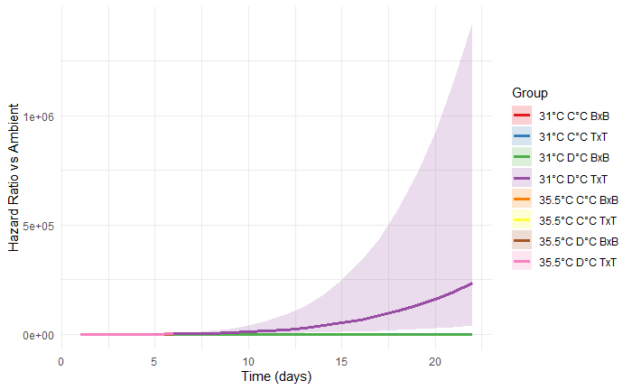

```r
ggsave("C:/Users/jc980786/OneDrive - James Cook University/GitHub/Larval.Infect.Exp/figures/DHW_plot.png", width = 8, height = 6, dpi = 300)
```

Summary figure

Line graphs of all traits (means)

```r
###  Size  ###
summary_df_size_grouped <- df_with_extremes %>%
  mutate(
    Reef = Cross_2,
    DayNumber = Timepoint
  ) %>%
  group_by(DayNumber, Reef, CellType, Treatment) %>%
  summarise(
    mean_Area = mean(Area..mm.2., na.rm = TRUE),
    sd_Area = sd(Area..mm.2., na.rm = TRUE),
    n = n(),
    se = sd_Area / sqrt(n),
    ci_lower = mean_Area - qt(0.975, df = n - 1) * se,
    ci_upper = mean_Area + qt(0.975, df = n - 1) * se,
    .groups = "drop"
  )
```

[output not shown]